# Caret package, training and test sets, and overall accuracy

## Description

This is the first example for creating a ML model in *R*

## Notes

1. Add dependencies

```r
library(tidyverse)
library(caret)
library(dslabs)
library(e1071)
data(heights)
```

2. Define outputs **Y** & features **X**

```r
y <- heights$sex
x <- heights$height
```

We can create training $ test data sets with *caret* 3. Define sets

```r
set.seed(2007)
testIndex <- createDataPartition(y, 1, p = 0.5, list = FALSE)
trainSet <- heights[-testIndex, ]
testSet <- heights[testIndex, ]
```

# First ML algorithm

We’ll **guess** the output, from the testSet

```r
yHat <- sample(c("Male", "Female"), length(testIndex), replace = TRUE)
```

Like this, we don’t have Factors, which is recommended

```r
yHat <- sample(c("Male", "Female"), length(testIndex), replace = TRUE) %>% factor(levels = levels(testSet$sex))
```

Check the **mean** from the testSet

```r
mean(yHat == testSet$sex)
```

```
## [1] 0.5104762
```

But, males are higher than females. So…

```r
heights %>% group_by(sex) %>% summarize(mean(height), sd(height))
```

```
## # A tibble: 2 x 3
##   sex    `mean(height)` `sd(height)`
##   <fct>           <dbl>        <dbl>
## 1 Female           64.9         3.76
## 2 Male             69.3         3.61
```

## Predict male if height is within two std dv.

```r
yHat <- ifelse(x > 62, "Male", "Female") %>% factor(levels = levels(testSet$sex))
```

Check the **mean** from the testSet

```r
mean(yHat == testSet$sex)
```

```
## [1] 0.74
```

## Examine the accuracy we obtain with 10 different cutoffs

This is better than guessing, though!

```r
cutoff <- seq(61, 70)
accuracy <- map_dbl(cutoff, function(x) {
  yHat <- ifelse(trainSet$height > x, "Male", "Female") %>% factor(levels = levels(testSet$sex))
  mean(yHat == trainSet$sex)
})
```

Result from the cutoffs

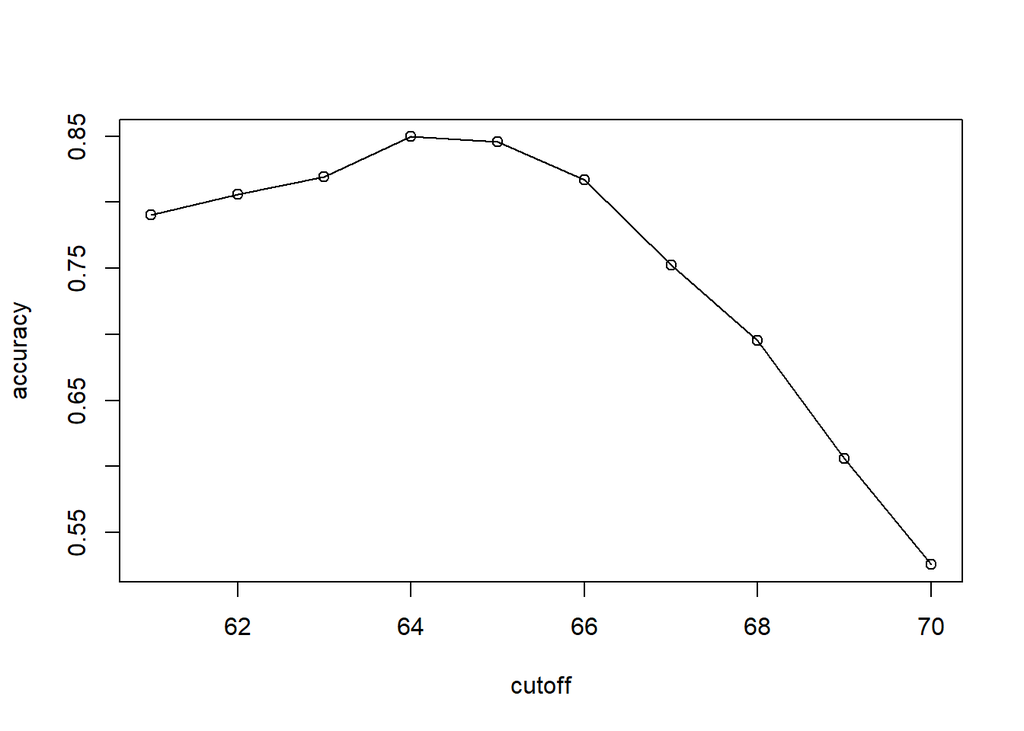

```r
plot(cutoff, accuracy, type = "o")
```

```r
bestCutoff <- cutoff[which.max(accuracy)]
```

## Check cutoff on the test data

```r
yHat <- ifelse(testSet$height > bestCutoff, "Male", "Female") %>% factor(levels = levels(testSet$sex))
yHat <- factor(yHat)
mean(yHat == testSet$sex)
```

```
## [1] 0.8038095
```

# Confusion matrix

Tabulates each combination of prediction and actual value

```r
table(predicted = yHat, actual = testSet$sex)
```

```
##          actual
## predicted Female Male
##    Female     48   32
##    Male       71  374
```

```r
testSet %>%
  mutate(yHat = yHat) %>%
  group_by(sex) %>%
  summarize(accuracy = mean(yHat == sex))
```

```
## # A tibble: 2 x 2
##   sex    accuracy
##   <fct>     <dbl>
## 1 Female    0.403
## 2 Male      0.921
```

```r
prev <- mean(y == "Male")
```

**Sensitivity**: Ability of an algorithm to predict a positive outcome when the actual outcome is positive. For FP

**Specificity**: Ability of an algorithm to not predict the positive. For TP

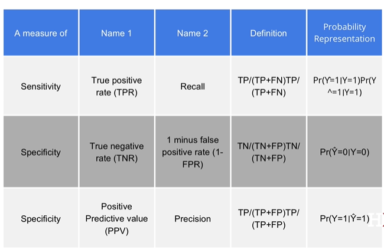

Table of probabilities

```r
confusionMatrix(data = yHat, reference = testSet$sex)
```

```
## Confusion Matrix and Statistics
##
##           Reference
## Prediction Female Male
##     Female     48   32
##     Male       71  374
##
##                Accuracy : 0.8038
##                  95% CI : (0.7672, 0.8369)
##     No Information Rate : 0.7733
##     P-Value [Acc > NIR] : 0.0513022
##
##                   Kappa : 0.3671
##
##  Mcnemar's Test P-Value : 0.0001809
##
##             Sensitivity : 0.40336
##             Specificity : 0.92118
##          Pos Pred Value : 0.60000
##          Neg Pred Value : 0.84045
##              Prevalence : 0.22667
##          Detection Rate : 0.09143
##    Detection Prevalence : 0.15238
##       Balanced Accuracy : 0.66227
##
##        'Positive' Class : Female
##
```

# Balanced accuracy and F1 score

**Balanced accuracy**: One number summary for specificity and sensitivity

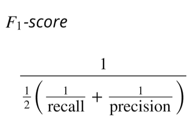

**Beta**: Represent how much more important sensitivity is compared to specificity

## Updating F|M height code

```r
cutoff <- seq(61, 70)
F_1 <- map_dbl(cutoff, function(x){
  yHat <- ifelse(trainSet$height > x, "Male", "Female") %>%
    factor(levels = levels(testSet$sex))
  F_meas(data = yHat, reference = factor(trainSet$sex)) # New!
})
max(F_1)
```

```
## [1] 0.6470588
```

```r
bestCutoff <- cutoff[which.max(F_1)]
yHat <- ifelse(testSet$height > bestCutoff, "Male", "Female") %>%
  factor(levels = levels(testSet$sex))
sensitivity(data = yHat, reference = testSet$sex) # New!
```

```
## [1] 0.6302521
```

```r
specificity(data = yHat, reference = testSet$sex) # New!
```

```
## [1] 0.8325123
```

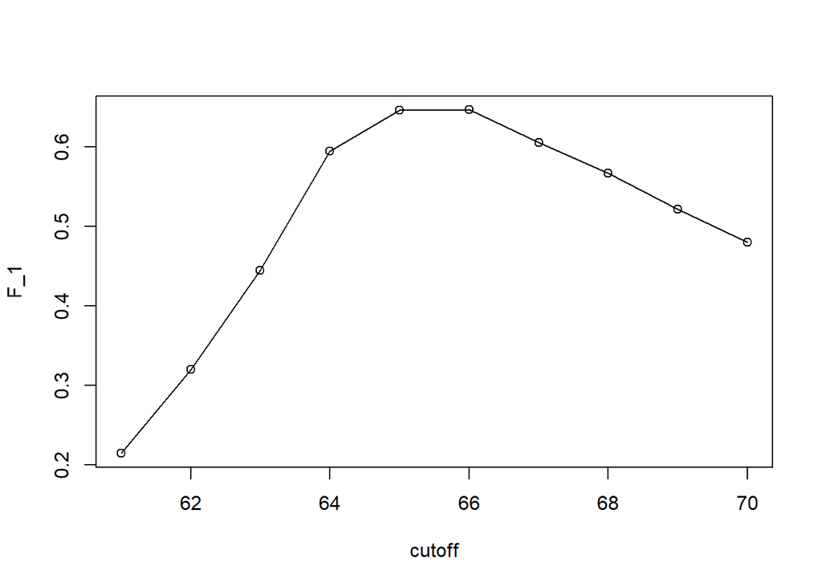

```r
plot(cutoff, F_1, type = "o")
```

# The ROC curve

For each parameter, we can get a different sensitivity and specificity. So, it’s necessary to compare both.

**Precision recall plot**: Give us the prevalance measure

```r
p <- 0.9
n <- length(testIndex)
yHat <- sample(c("Male", "Female"), n, replace = TRUE, prob=c(p, 1-p)) %>%
  factor(levels = levels(testSet$sex))
mean(yHat == testSet$sex)
```

```
## [1] 0.7390476
```

Getting ROC curve

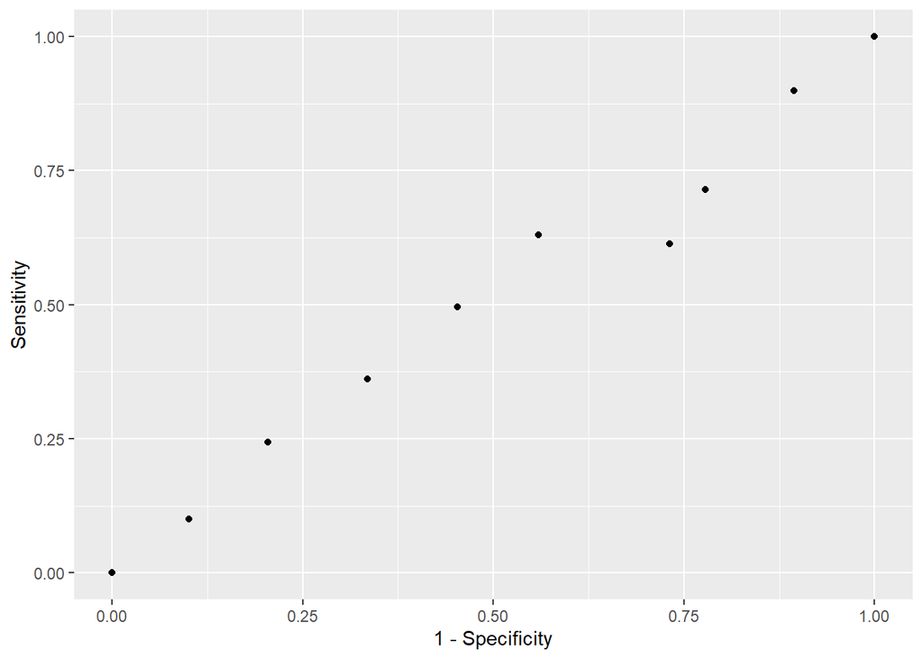

```r
# ROC curve
probs <- seq(0, 1, length.out = 10)
guessing <- map_df(probs, function(p){
  yHat <-
    sample(c("Male", "Female"), n, replace = TRUE, prob=c(p, 1-p)) %>%
    factor(levels = c("Female", "Male"))
  list(method = "Guessing",
       FPR = 1 - specificity(yHat, testSet$sex),
       TPR = sensitivity(yHat, testSet$sex))
})
guessing %>% qplot(FPR, TPR, data =., xlab = "1 - Specificity", ylab = "Sensitivity")
```

```r
cutoffs <- c(50, seq(60, 75), 80)
height_cutoff <- map_df(cutoffs, function(x){
  yHat <- ifelse(testSet$height > x, "Male", "Female") %>%
    factor(levels = c("Female", "Male"))
   list(method = "Height cutoff",
        FPR = 1-specificity(yHat, testSet$sex),
        TPR = sensitivity(yHat, testSet$sex))
})
```

Plot both curves together

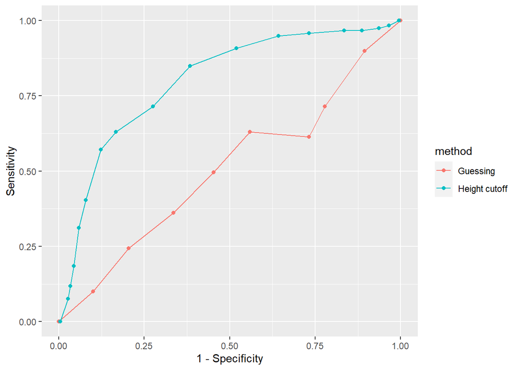

```r
# plot both curves together
bind_rows(guessing, height_cutoff) %>%
  ggplot(aes(FPR, TPR, color = method)) +
  geom_line() +
  geom_point() +
  xlab("1 - Specificity") +
  ylab("Sensitivity")
```

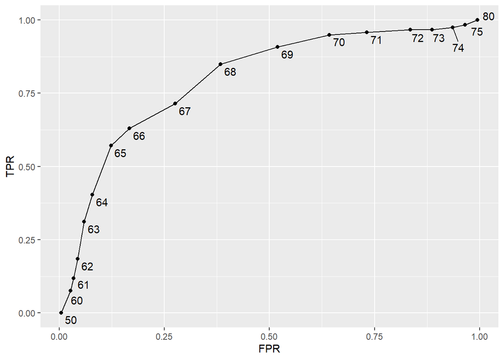

```r
library(ggrepel)
map_df(cutoffs, function(x){
  yHat <- ifelse(testSet$height > x, "Male", "Female") %>%
    factor(levels = c("Female", "Male"))
   list(method = "Height cutoff",
        cutoff = x,
        FPR = 1-specificity(yHat, testSet$sex),
        TPR = sensitivity(yHat, testSet$sex))
}) %>%
  ggplot(aes(FPR, TPR, label = cutoff)) +
  geom_line() +
  geom_point() +
  geom_text_repel(nudge_x = 0.01, nudge_y = -0.01)
```

Plot precision vs recal

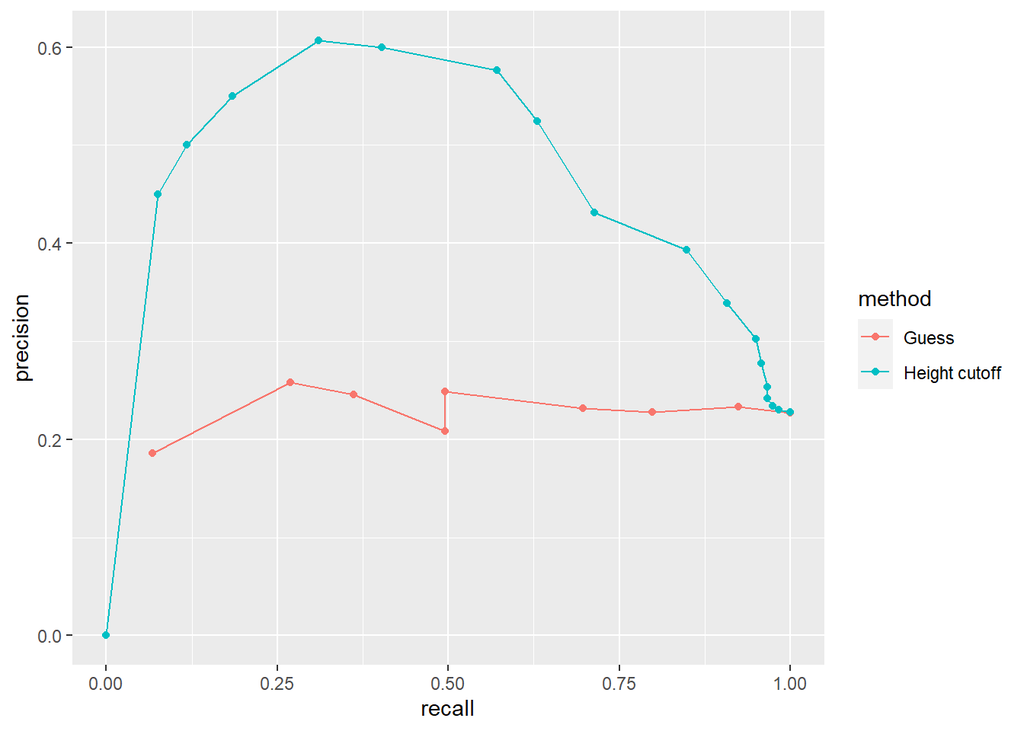

```r
# plot precision against recall
guessing <- map_df(probs, function(p){
  yHat <- sample(c("Male", "Female"), length(testIndex),
                  replace = TRUE, prob=c(p, 1-p)) %>%
    factor(levels = c("Female", "Male"))
  list(method = "Guess",
    recall = sensitivity(yHat, testSet$sex),
    precision = precision(yHat, testSet$sex))
})

height_cutoff <- map_df(cutoffs, function(x){
  yHat <- ifelse(testSet$height > x, "Male", "Female") %>%
    factor(levels = c("Female", "Male"))
  list(method = "Height cutoff",
       recall = sensitivity(yHat, testSet$sex),
    precision = precision(yHat, testSet$sex))
})

bind_rows(guessing, height_cutoff) %>%
  ggplot(aes(recall, precision, color = method)) +
  geom_line() +
  geom_point()
```

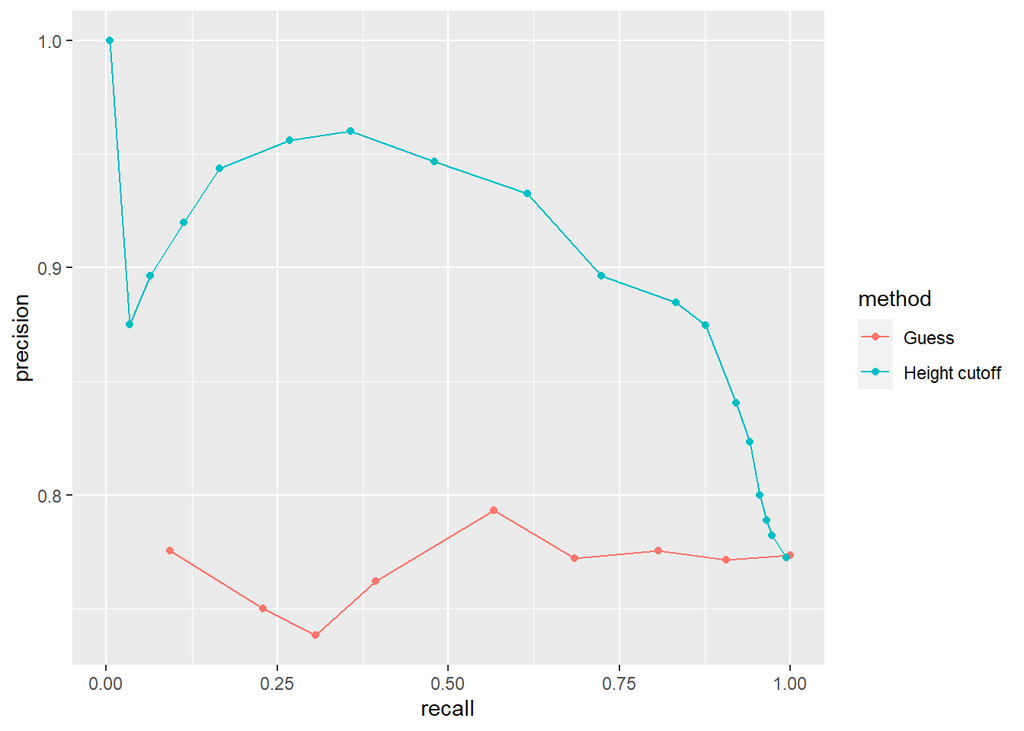

```r
guessing <- map_df(probs, function(p){
  yHat <- sample(c("Male", "Female"), length(testIndex), replace = TRUE,
                  prob=c(p, 1-p)) %>%
    factor(levels = c("Male", "Female"))
  list(method = "Guess",
    recall = sensitivity(yHat, relevel(testSet$sex, "Male", "Female")),
    precision = precision(yHat, relevel(testSet$sex, "Male", "Female")))
})

height_cutoff <- map_df(cutoffs, function(x){
  yHat <- ifelse(testSet$height > x, "Male", "Female") %>%
    factor(levels = c("Male", "Female"))
  list(method = "Height cutoff",
       recall = sensitivity(yHat, relevel(testSet$sex, "Male", "Female")),
    precision = precision(yHat, relevel(testSet$sex, "Male", "Female")))
})
bind_rows(guessing, height_cutoff) %>%
  ggplot(aes(recall, precision, color = method)) +
  geom_line() +
  geom_point()
```

# Conditional probabilities

- Bayes’ Rule
- Good estimate of **p(x)** will suffice to build optimal predictors
- P(Y = y | X = x) **Expectation**: Probability of randomly picking a value since the avg is a proportion of it

**THE Best** in general is by defining a **Loss function** - Squared loss function: (YHat -Y)^2 - As close to 0 as possible

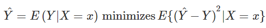